# Easily Scrape and Process AFL Data

James Day

2018-11-07

# fitzRoy

[figure not shown]

## Overview

The goal of fitzRoy is to provide a set of functions that allows for users to easily get access to AFL data from sources such as afltables.com and footywire.com. There are also tools for processing and cleaning that data. Future versions will include basic ELO processing functions.

## Installation

You can install fitzRoy from github with:

```r
# install.packages("devtools")
devtools::install_github("jimmyday12/fitzRoy")
```

## Usage

The `fitzRoy` package can be used to simply get data from various sources. Some minimal working examples are below.

### Getting Data

Primarily, the tool can be used to access data from various sources. Data is included in the package and can be access directly however this will not be up to date. Each source of data has functions for updating data during the season.

### AFL Tables match results

You can access the basic afl tables match results data. This includes all matches from 1897-current. It is generally updated on the day after a round finishes.

You can access the data directly from the package using `match_results`. This will be updated periodically but you will need to update your R package to get access to the latest data. It is better to use `get_match_results` directly, as this will give you up to date results.

```r
library(fitzRoy)
results <- get_match_results()

tail(results)
```

```
## # A tibble: 6 x 16
##    Game Date       Round Home.Team Home.Goals Home.Behinds Home.Points
##   <dbl> <date>     <chr> <chr>          <int>        <int>       <int>
## 1 15402 2018-09-08 QF    West Coa…         12           14          86
## 2 15403 2018-09-14 SF    Melbourne         16            8         104
## 3 15404 2018-09-15 SF    Collingw…          9           15          69
## 4 15405 2018-09-21 PF    Collingw…         15            7          97
## 5 15406 2018-09-22 PF    West Coa…         18           13         121
## # ... with 1 more row, and 9 more variables: Away.Team <chr>,
## #   Away.Goals <int>, Away.Behinds <int>, Away.Points <int>, Venue <chr>,
## #   Margin <int>, Season <dbl>, Round.Type <chr>, Round.Number <int>
```

You can also convert this format into a more analysis friendly “long” format using the helper function `convert_results`.

```r
results_long <- convert_results(results)

head(results_long)
```

```
## # A tibble: 6 x 13
##    Game Date       Round Venue Margin Season Round.Type Round.Number Status
##   <dbl> <date>     <chr> <chr>  <dbl>  <dbl> <chr>             <int> <chr>
## 1     1 1897-05-08 R1    Brun…     33   1897 Regular               1 Home
## 2     1 1897-05-08 R1    Brun…    -33   1897 Regular               1 Away
## 3     2 1897-05-08 R1    Vict…     25   1897 Regular               1 Home
## 4     2 1897-05-08 R1    Vict…    -25   1897 Regular               1 Away
## 5     3 1897-05-08 R1    Cori…    -23   1897 Regular               1 Home
## # ... with 1 more row, and 4 more variables: Behinds <chr>, Goals <chr>,
## #   Points <chr>, Team <chr>
```

### AFL Tables player results

A new function will return all detailed player stats from afltables.com. Primarily, the easiest way to use this is simply to call `get_afltables_stats` with your required `start_date` and `end_date`.

```r
stats <- get_afltables_stats(start_date = "2000-01-01", end_date = "2018-06-01")
```

```
## Returning data from 2000-01-01 to 2018-06-01
```

```
## Finished getting afltables data
```

```r
tail(stats)
```

```
## # A tibble: 6 x 59
##   Season Round Date       Local.start.time Venue Attendance Home.team  HQ1G
##    <dbl> <chr> <date>                <int> <chr>      <int> <chr>     <int>
## 1   2018 10    2018-05-27             1440 "Per…      37575 Fremantle     3
## 2   2018 10    2018-05-27             1440 "Per…      37575 Fremantle     3
## 3   2018 10    2018-05-27             1440 "Per…      37575 Fremantle     3
## 4   2018 10    2018-05-27             1440 "Per…      37575 Fremantle     3
## 5   2018 10    2018-05-27             1440 "Per…      37575 Fremantle     3
## # ... with 1 more row, and 51 more variables: HQ1B <int>, HQ2G <int>,
## #   HQ2B <int>, HQ3G <int>, HQ3B <int>, HQ4G <int>, HQ4B <int>,
## #   Home.score <int>, Away.team <chr>, AQ1G <int>, AQ1B <int>, AQ2G <int>,
## #   AQ2B <int>, AQ3G <int>, AQ3B <int>, AQ4G <int>, AQ4B <int>,
## #   Away.score <int>, First.name <chr>, Surname <chr>, ID <int>,
## #   Jumper.No. <dbl>, Playing.for <chr>, Kicks <dbl>, Marks <dbl>,
## #   Handballs <dbl>, Goals <dbl>, Behinds <dbl>, Hit.Outs <dbl>,
## #   Tackles <dbl>, Rebounds <dbl>, Inside.50s <dbl>, Clearances <dbl>,
## #   Clangers <dbl>, Frees.For <dbl>, Frees.Against <dbl>,
## #   Brownlow.Votes <dbl>, Contested.Possessions <dbl>,
## #   Uncontested.Possessions <dbl>, Contested.Marks <dbl>,
## #   Marks.Inside.50 <dbl>, One.Percenters <dbl>, Bounces <dbl>,
## #   Goal.Assists <dbl>, Time.on.Ground.. <int>, Substitute <int>,
## #   Umpire.1 <chr>, Umpire.2 <chr>, Umpire.3 <chr>, Umpire.4 <chr>,
## #   group_id <int>
```

### Fixture

You can access the fixture using `get_fixture` function. This will download the fixture for the current calendar year by default.

```r
fixture <- get_fixture()

head(fixture)
```

```
## # A tibble: 6 x 7
##   Date                Season Season.Game Round Home.Team  Away.Team Venue
##   <dttm>               <int>       <int> <dbl> <chr>      <chr>     <chr>
## 1 2018-03-22 19:25:00   2018           1     1 Richmond   Carlton   MCG
## 2 2018-03-23 19:50:00   2018           1     1 Essendon   Adelaide  Marve…
## 3 2018-03-24 15:35:00   2018           1     1 St Kilda   Brisbane… Marve…
## 4 2018-03-24 16:05:00   2018           1     1 Port Adel… Fremantle Adela…
## 5 2018-03-24 18:25:00   2018           1     1 Gold Coast North Me… Cazal…
## # ... with 1 more row
```

### Footywire Advanced Player Stats

Footywire data is available in the form of advanced player match statistics from 2010 games onwards. This is when advanced statistics became available.

Footywire data from 2010-2017 is included in the package. This will be updated periodically but you will need to update your R package to get access to the latest data.

```r
## Show the top of player_stats
head(fitzRoy::player_stats)
```

```
##         Date Season   Round Venue         Player     Team Opposition
## 1 2010-03-25   2010 Round 1   MCG Daniel Connors Richmond    Carlton
## 2 2010-03-25   2010 Round 1   MCG Daniel Jackson Richmond    Carlton
## 3 2010-03-25   2010 Round 1   MCG  Brett Deledio Richmond    Carlton
## 4 2010-03-25   2010 Round 1   MCG    Ben Cousins Richmond    Carlton
## 5 2010-03-25   2010 Round 1   MCG  Trent Cotchin Richmond    Carlton
## 6 2010-03-25   2010 Round 1   MCG  Dustin Martin Richmond    Carlton
##   Status Match_id CP UP ED   DE CM GA MI5 One.Percenters BO TOG  K HB  D M
## 1   Home     5089  8 15 16 66.7  0  0   0              1  0  69 14 10 24 3
## 2   Home     5089 11 10 14 60.9  1  0   0              0  0  80 11 12 23 2
## 3   Home     5089  7 14 16 76.2  0  0   0              0  0  89 12  9 21 5
## 4   Home     5089  9 10 11 57.9  0  1   0              0  0  69 13  6 19 1
## 5   Home     5089  8 10 13 68.4  1  0   0              0  1  77 11  8 19 6
## 6   Home     5089  6 12 16 88.9  0  0   0              1  0  81  5 13 18 4
##   G B T HO GA1 I50 CL CG R50 FF FA AF SC CCL SCL SI MG TO ITC T5
## 1 0 0 1  0   0   2  2  4   6  2  0 77 85  NA  NA NA NA NA  NA NA
## 2 0 0 5  0   0   8  5  4   1  2  0 85 89  NA  NA NA NA NA  NA NA
## 3 1 0 6  0   0   4  3  4   3  1  2 94 93  NA  NA NA NA NA  NA NA
## 4 1 0 1  0   1   1  2  3   4  1  0 65 70  NA  NA NA NA NA  NA NA
## 5 0 0 1  0   0   2  3  3   2  0  2 65 63  NA  NA NA NA NA  NA NA
## 6 0 0 3  0   0   2  3  1   0  0  1 62 72  NA  NA NA NA NA  NA NA
```

We can also use the `update_footywire_stats` function to get the most up to date data. This will merge data from 2010-current with any new data points.

```r
## Update footywire data
dat <- update_footywire_stats()
```

```
## Getting match ID's...
```

```
##
## Checking Github
```

```
## Getting data from footywire.com
```

```
## Finished getting data
```

```r
tail(dat)
```

```
##             Date Season       Round Venue            Player        Team
## 80515 2018-09-29   2018 Grand Final   MCG    Tyson Goldsack Collingwood
## 80516 2018-09-29   2018 Grand Final   MCG         Mason Cox Collingwood
## 80517 2018-09-29   2018 Grand Final   MCG   Brayden Maynard Collingwood
## 80518 2018-09-29   2018 Grand Final   MCG Jaidyn Stephenson Collingwood
## 80519 2018-09-29   2018 Grand Final   MCG    Levi Greenwood Collingwood
## 80520 2018-09-29   2018 Grand Final   MCG        James Aish Collingwood
##       Opposition Status Match_id CP UP ED   DE CM GA MI5 One.Percenters BO
## 80515 West Coast   Away     9720  6  4  8 88.9  0  0   0              7  0
## 80516 West Coast   Away     9720  6  4  6 66.7  3  0   3              7  0
## 80517 West Coast   Away     9720  1  7  8 88.9  0  0   0              2  0
## 80518 West Coast   Away     9720  3  5  7 77.8  0  0   0              0  0
## 80519 West Coast   Away     9720  3  7  2 25.0  0  0   0              0  0
## 80520 West Coast   Away     9720  4  4  5 71.4  0  0   0              0  0
##       TOG K HB D M G B T HO GA1 I50 CL CG R50 FF FA AF SC CCL SCL SI  MG
## 80515  90 1  8 9 0 0 0 3  0   0   0  0  0   1  1  0 32 53   0   0  0 -22
## 80516  92 9  0 9 7 2 0 4  8   0   0  0  1   1  1  1 82 90   0   0  2 258
## 80517  80 7  2 9 2 0 0 7  0   0   2  0  1   4  0  0 59 51   0   0  2 261
## 80518  73 6  3 9 2 2 0 3  0   0   2  0  2   1  0  0 54 47   0   0  5 135
## 80519  79 4  4 8 1 0 0 5  0   0   1  0  3   0  1  0 44 23   0   0  1  97
## 80520  69 5  2 7 2 0 0 5  0   0   1  1  1   2  1  0 46 40   0   1  1 123
##       TO ITC T5
## 80515  1   6  0
## 80516  4   1  1
## 80517  4   1  0
## 80518  2   1  3
## 80519  3   1  1
## 80520  2   4  1
```

### Weather

We have also included weather data for the 2017 season. This is a work in progress but includes rainfall data from the nearest observation station to each ground. This data is included in the package as `results_weather`.

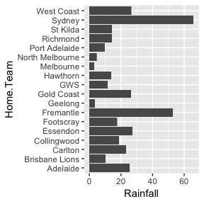

```r
library(ggplot2)
library(dplyr)

# Get 2017 weather data
weather <- fitzRoy::results_weather %>%
  filter(Season == 2017)

# Plot total rainfal for each home team
ggplot2::ggplot(dat = weather, ggplot2::aes(x = Home.Team, y = Rainfall)) +
  ggplot2::geom_col() +
  ggplot2::coord_flip()
```

### Squiggle Data

```r
# You can get the sources
sources <- get_squiggle_data("sources")
head(sources)
```

```
##   id                  name                                url
## 1  1              Squiggle      https://live.squiggle.com.au/
## 2  2               The Arc           https://thearcfooty.com/
## 3  3        Figuring Footy          http://figuringfooty.com/
## 4  4       Matter of Stats      http://www.matterofstats.com/
## 5  5               Punters
## 6  6 Footy Maths Institute https://footymaths.blogspot.com.au
```

```r
# Get all tips
tips <- get_squiggle_data("tips")
head(tips)
```

```
##   correct             updated   err tipteamid ateamid
## 1       1 2017-07-11 13:59:46 42.00        14      14
## 2       1 2017-04-10 12:18:02    NA        14      14
## 3       0 2017-07-11 13:59:46 48.39         3      14
## 4       1 2017-07-11 13:59:46  3.69        18      18
## 5       1 2017-07-11 13:59:46  3.00        18      18
## 6       1 2017-07-11 13:59:46 53.00         1       9
##                    ateam margin         venue       hteam          source
## 1               Richmond   1.00        M.C.G.     Carlton        Squiggle
## 2               Richmond     NA        M.C.G.     Carlton  Figuring Footy
## 3               Richmond   5.39        M.C.G.     Carlton Matter of Stats
## 4       Western Bulldogs  10.31        M.C.G. Collingwood Matter of Stats
## 5       Western Bulldogs  17.00        M.C.G. Collingwood        Squiggle
## 6 Greater Western Sydney   3.00 Adelaide Oval    Adelaide        Squiggle
##   sourceid hteamid    bits gameid              tip hconfidence round year
## 1        1       3  0.0000      1         Richmond        50.0     1 2017
## 2        3       3  0.2141      1         Richmond        42.0     1 2017
## 3        4       3 -0.2076      1          Carlton        56.7     1 2017
## 4        4       4  0.3265      2 Western Bulldogs        37.3     1 2017
## 5        1       4  0.3103      2 Western Bulldogs        38.0     1 2017
## 6        1       1  0.0000      8         Adelaide        50.0     1 2017
##                  date confidence
## 1 2017-03-23 19:20:00       50.0
## 2 2017-03-23 19:20:00       58.0
## 3 2017-03-23 19:20:00       56.7
## 4 2017-03-24 19:50:00       62.7
## 5 2017-03-24 19:50:00       62.0
## 6 2017-03-26 15:20:00       50.0
```

```r
# Get` just tips from round 1, 2018
tips <- get_squiggle_data("tips", round = 1, year = 2018)
head(tips)
```

```
##   sourceid round      tip    hteam gameid hconfidence confidence    bits
## 1        1     1 Adelaide Essendon    373       44.00      56.00 -0.1844
## 2        2     1 Adelaide Essendon    373       40.20      59.80 -0.3147
## 3        4     1 Adelaide Essendon    373       40.50      59.50 -0.3040
## 4        5     1 Essendon Essendon    373       52.08      52.08  0.0588
## 5        6     1 Adelaide Essendon    373       34.00      66.00 -0.5564
## 6        7     1 Adelaide Essendon    373       44.84      55.16 -0.1571
##   margin                date    ateam correct year hteamid     venue
## 1  11.00 2018-03-23 19:50:00 Adelaide       0 2018       5 Docklands
## 2   9.00 2018-03-23 19:50:00 Adelaide       0 2018       5 Docklands
## 3   9.78 2018-03-23 19:50:00 Adelaide       0 2018       5 Docklands
## 4     NA 2018-03-23 19:50:00 Adelaide       1 2018       5 Docklands
## 5  21.00 2018-03-23 19:50:00 Adelaide       0 2018       5 Docklands
## 6   8.00 2018-03-23 19:50:00 Adelaide       0 2018       5 Docklands
##   ateamid                source   err             updated tipteamid
## 1       1              Squiggle 23.00 2018-03-23 22:54:38         1
## 2       1               The Arc 21.00 2018-03-23 22:54:38         1
## 3       1       Matter of Stats 21.78 2018-03-23 22:54:38         1
## 4       1               Punters    NA 2018-03-23 22:54:38         5
## 5       1 Footy Maths Institute 33.00 2018-03-23 22:54:38         1
## 6       1            PlusSixOne 20.00 2018-03-23 22:54:38         1
```

## Docker Support

fitzRoy now provides [Docker](https://www.docker.com/get-started) support in the form of an image hosted on [DockerHub](https://hub.docker.com/r/jimmyday12/fitzroy/).

### Usage

Once you have the images, (e.g. `docker pull jimmyday12/fitzroy:latest`) run one of the following commands.

- To start [RStudio](https://www.rstudio.com/) with Fitzroy ready to use:
- `docker run -d -p 8787:8787 --name fitzroy jimmyday12/fitzroy:latest` and open http://localhost:8787. *(Username: `rstudio`, Password: `rstudio`)
- To start an R terminal prompt with fitzRoy ready to use:
- `docker run -it jimmyday12/fitzroy:latest R` to start with an R terminal prompt.
- Run `quit()` to exit the container

### Building the image locally

To build the Docker image run the following from the root of the repository.

- `docker build -t jimmyday12/fitzroy:latest -f docker/rstudio/Dockerfile .`